# Causal Inference with Machine Learning

Simon Naitram

2019-07-25

Abstract

In this workshop, we combine two important trends in economics—the causal inference framework and the power of machine learning. We discuss the importance of causal effects for policy. Then we show how causal inference—the estimation of average treatment effects—can be described as a prediction problem, particularly in the context of selection bias. We then examine the concept and language of machine learning. We introduce some machine learning methods and show how they can be implemented in R. Throughout, we use a simulated example to show how machine learning can help us to identify causal effects that are important for economic policy.

```r
knitr::opts_chunk$set(echo = TRUE, cache=TRUE, results='hold', set.seed(123))

# Load all packages needed to execute the job
# If the packages are not installed, write
# install.packages("<name of package>")

library(knitr)
library(tidyverse)
library(caret)
library(rpart)
library(rpart.plot)
library(randomForest, warn.conflicts = FALSE, quietly = T)
library(gbm)

options(scipen = 999)
set.seed(123)
```

## Causal Inference for Economic Policy

Causal inference is vital for good economic policymaking. Without a clear understanding of what causal effect a proposed policy intervention will have, we are driving with a blindfold.

Establishing causality in macroeconomics is especially difficult. We do not have access to randomized trials. We cannot conduct experiments on the macroeconomy. The result is that the most important questions in macroeconomics remain the same. Identification of causal effects is very difficult in macroeconomics.

Over the past decade, a new breed of macroeconomist has taken a more humble approach to policymaking. We break the macroeconomy into smaller bits and focus on one piece at a time. We focus on understanding the microfoundations of the macroeconomy—how do people respond to economic policy changes and to economic shocks? Noah Smith calls this ‘micro-focused macro’. We can leverage the power of the credibility revolution in economics to make better macroeconomic policy. This is the causal inference approach to macroeconomics.

Examples of this type of work include disaggregating wage data to understand price and wage stickiness (Bils, Klenow, Malin 2016), measuring differences in consumption by age (Wong 2016), measuring differences in cyclical employment pattens by age (Forsyth 2016), or measuring consumption responses to changes in house prices (Stroebel and Vavra 2014). Throughout this workshop, we work with a simple hypothetical micro-focused macroeconomic example: *what is the effect of tax refunds on consumption?*

Scott Cunningham refers to causal inference as ‘the space between theory and estimation.’ Identifying causal effects requires applying theoretical assumptions to economic data. It requires us to use a substantial amount of both economic theory and statistical prowess. The method of causal inference is to find plausibly exogenous variation in policy. One means of finding exogenous variation is the ‘natural experiment’. Natural experiments are events or policies that resemble controlled experiments—some agents are treated, some are not.

There are lots of methods of identifying causal effects. I suggest if you’re not familiar with these, you try Joshua Angrist and Jorn-Steffen Pischke’s “Mostly Harmless Econometrics” or even Guido Imbens and Donald Rubin’s “Causal Inference for Statistics”. In this workshop, we focus on a single stream of identifying causal effects—the simplest really, and one where you can easily see the application of machine learning to causality, and the application of causality to macroeconomics.

## Average Treatment Effect

Policymaking is inherently a prediction problem. The reason we need to know the causal effect of a policy is so that we can *predict* its impact on the economy. Making optimal policy requires knowledge of the **counterfactual** payoffs from alternative policy decisions.

Identifying causal effects is about estimating those counterfactuals. We need to know the difference between how people would behave *if we implemented the policy* versus how they would behave *if we didn’t implement the policy*, all else constant.

Let’s show a simple example of that. Suppose the government wants to pay households income tax refunds. What would be the causal effect of the income tax refund on household spending?

First, let’s imagine we can observe the **potential outcomes** for each of ten households. The value $Y_0$ represents what their spending would be if they don’t receive the refund. The value $Y_1$ represents what their spending would be if they receive the refund.

```r
set.seed(123)
returns <- data.frame(Household=seq(1,10,1),
                      Y_1=sample(seq(5,15,1), 10, replace=T),
                      Y_0=sample(seq(2,10,1), 10, replace=T)) #random samples from two different distributions
returns <- returns %>% mutate(tau=Y_1-Y_0)  #tau is the treatment effect for each individual
kable(returns)
```

| Household | Y_1 | Y_0 | tau |
| --- | --- | --- | --- |
| 1 | 8 | 10 | -2 |
| 2 | 13 | 6 | 7 |
| 3 | 9 | 8 | 1 |
| 4 | 14 | 7 | 7 |
| 5 | 15 | 2 | 13 |
| 6 | 5 | 10 | -5 |
| 7 | 10 | 4 | 6 |
| 8 | 14 | 2 | 12 |
| 9 | 11 | 4 | 7 |
| 10 | 10 | 10 | 0 |

If we can observe both potential outcomes, then the **Average Treatment Effect** (ATE) is simply the average of households’ differences between $Y_1$ and $Y_0$. We calculate $\tau$ for each household, and take the mean.

```r
tau <- mean(returns$tau) #take the average difference between potential outcomes
print(tau)
```

```
## [1] 4.6
```

*On average*, receiving a refund would lead to higher spending by an amount $\tau$. This is the causal effect of income tax refunds on household spending. The Average Treatment Effect (ATE) is therefore the main value we search for in causal inference.

In reality, however, we only observe a single outcome for each household: either $Y_0$ or $Y_1$. So what if we observe a single outcome $Y$ and an indicator for whether they were treated or not?

```r
set.seed(123)
actual <- returns %>% mutate(D=sample(c(0,1),10, replace=T, prob=c(0.5,0.5))) #create a random treatment, D
actual <- actual %>% mutate(Y=ifelse(D==0,Y_0,Y_1)) %>% select(-Y_0,-Y_1,-tau) #if D=0, use Y_0; if D=1, use Y_1
kable(actual)
```

| Household | D | Y |
| --- | --- | --- |
| 1 | 1 | 8 |
| 2 | 0 | 6 |
| 3 | 1 | 9 |
| 4 | 0 | 7 |
| 5 | 0 | 2 |
| 6 | 1 | 5 |
| 7 | 0 | 4 |
| 8 | 0 | 2 |
| 9 | 0 | 4 |
| 10 | 1 | 10 |

In the real world, we can’t calculate the difference in potential outcomes for each individual. The first thing we *can do*, however, is to calculate the **Simple Difference in Mean Outcomes** (SDO). The SDO is the difference between the average outcome for the treated (D=1) and the average outcome for the control (D=0).

```r
Y1 <- actual$Y[which(actual$D==1)] #get only values for those who were treated
Y0 <- actual$Y[which(actual$D==0)] #get only values for those who weren't treated
EY_1 <- mean(Y1) #take the means
EY_0 <- mean(Y0)
SDO <- EY_1-EY_0 #find the difference between the means
print(SDO)
```

```
## [1] 3.833333
```

Notice that this Simple Difference in Mean Outcomes (SDO) can also be estimated directly from a regression with the observed outcome $Y$ as the dependent variable and treatment assignment $D$ as the independent variable:

$$Y_i=\alpha + \tau \cdot D_i + \varepsilon_i$$

This also makes it easy for us to calculate standard errors for the estimate of $\tau$. Let’s do this in R.

```r
#lm() is the linear model function
#Y~D is how we express the formula
#no need for the intercept, it is added automatically
mod_1 <- lm(Y~D, data=actual)
summary(mod_1)
```

```
##
## Call:
## lm(formula = Y ~ D, data = actual)
##
## Residuals:
##      Min       1Q   Median       3Q      Max
## -3.00000 -1.66667 -0.08333  1.62500  2.83333
##
## Coefficients:
##             Estimate Std. Error t value Pr(>|t|)
## (Intercept)   4.1667     0.8519   4.891  0.00121 **
## D             3.8333     1.3469   2.846  0.02161 *
## ---
## Signif. codes:  0 '***' 0.001 '**' 0.01 '*' 0.05 '.' 0.1 ' ' 1
##
## Residual standard error: 2.087 on 8 degrees of freedom
## Multiple R-squared:  0.5031, Adjusted R-squared:  0.441
## F-statistic:   8.1 on 1 and 8 DF,  p-value: 0.02161
```

$$\text{SDO = Average Treatment Effect + Selection Bias}$$

**Selection bias arises if there is some inherent difference between two groups.** Suppose, for example, that we were observing an actual policy intervention by the government. An optimising government might choose to *select* rather than *randomly assign* who gets the refund. In particular, a government might choose to give poorer households their refunds first.

- Because poorer households get the refund, we might observe that their average consumption would be *lower* compared to the control group, even after getting the refund.
- If poorer households spend a greater portion of their extra income (higher marginal propensity to consume), we might observe that the *increase* in consumption is greater than the true causal effect.

Selection bias sometimes might even be so large as to completely mask the causal effect of the refund policy.

If assignment is purely at random, there is no selection bias. Randomized trials are therefore the ideal solution to the selection bias problem. The SDO would be equal to the ATE. But in macroeconomics, we very rarely have access to experiments or to problems that can be solved by experiment.

Here are some silly examples of where selection bias might arise:

- **More police in precincts with higher crime; does that mean that police cause crime?**
  - Policy decision: Should we add more police to a given district?’
  - Counterfactual: It is likely data was generated by a decision rule that said ‘add more police to areas with high crime.’ This may have reduced crime over what it would have been, but these areas may still have had high crime.
- **Lots of people die in hospitals, are hospitals bad for your health?**
  - Policy decision: Should I go to hospital for treatment?
  - Counterfactual: If I go to hospital will be better off than I would have been if I didn’t go?
- **Advertise more in December, sell more in December. But what is the causal impact of ad spending on sales?**
  - Policy decision: How much should I spend on advertising?
  - Counterfactual: What would my sales be if I would have advertised less?
- **High unemployment levels occur when government spending is high.**
  - Policy decision: should we lower unemployment by cutting government spending?
  - Counterfactual: What would have unemployment been if government spending didn’t increase? And how much of the increase in government spending is due to automatic stabilisers?

The goal of much modern empirical economics research is to overcome this selection bias in order to say something useful about the causal effect. Since we’re making policy proposals for the entire population, we need to worry about what effect our policies will have on the entire population. In order to solve this selection bias problem, we need some mechanism that makes our natural experiment approximate random assignment. Random assignment solves the selection problem by making treatment independent of potential outcomes.

## ATE with Selection Bias

Let us create a larger dataset to see what happens to our tax refund example when there is selection bias. First let’s create a datast without bias. We create a full dataset with each individual’s sex, eduction, location, number of children and their income. For each individual, their consumption when not receiving the refund (outcome not treated $Y_0$) is based on their income and the number of children they have. Their consumption when receiving the refund (outcome when treated $Y_1$) is a function of $Y_0$, their income, number of children, education, and sex. We then assign each of 10,0000 individuals to treatment randomly.

```r
set.seed(123)
#create a new dataset with 10,000 observations
exp <- data.frame(Household=seq(1,10000,1),
                  sex = sample(c("female","male"), 10000, replace=TRUE, prob = c(0.53, 0.47)),
                  education = factor(sample(c("secondary","post-secondary","undergrad","postgrad"), 10000,
                    replace=TRUE, prob = c(0.4, 0.3,0.2,0.1)), levels=c("secondary","post-secondary","undergrad","postgrad")),
                  location=factor(sample(c("urban","suburban"), 10000, replace=TRUE, prob = c(0.31, 0.69)),
                    levels=c("suburban", "urban")),
                  children=sample(seq(0:5), 10000, replace=TRUE),
                  income=rlnorm(10000, meanlog = 8, sdlog = 0.4))

#each household gets an extra 1000
#the difference between Y_0 and Y_1 is some function of income, children, education, and sex
exp <- exp %>% mutate(Y_0 = rnorm(n=10000, mean=(0.75*income + 50*children)),
                      Y_1 = Y_0 + 1000*(-100*(1/income) + 0.2*children + -0.1*as.numeric(education) + 0.1*as.numeric(sex)))

#random assignment to treatment
exp <- exp %>% mutate(D=sample(c(0,1), 10000, replace=T, prob=c(0.5,0.5)))
exp <- exp %>% mutate(Y=ifelse(D==0,Y_0,Y_1))
exp <- exp %>% mutate(tau=Y_1-Y_0)

#introducing selection bias by identifying households to drop
exp <- exp %>% mutate(drop=ifelse((income>7500 & D==1) |               #drop treated with high incomes
                                    (children==0 & D==1) |             #drop treated with no children
                                    (education=="secondary" & D==1) |  #drop treated with secondary education
                                    (sex=="male" & D==1) |             #drop treated males
                                    (children>4 & D==0) |              #drop controls with lots of children
                                    (income>7500 & D==0), 1, 0))       #drop controls with high incomes

#we don't actually drop them all, we randomly drop half of those identified above
prob <- 0.5
drop_from_treat <- sample(which(exp$drop==1), round(prob * sum(exp$drop==1)))
exp <- exp[-drop_from_treat,]

#estimate correct ATE
tau <- mean(exp$tau)
print(tau)

#estimate SDO with selection bias
mod_SDO <- lm(Y~D, data=exp)
summary(mod_SDO)
```

```
## [1] 548.1101
##
## Call:
## lm(formula = Y ~ D, data = exp)
##
## Residuals:
##     Min      1Q  Median      3Q     Max
## -2406.5  -732.6  -164.8   559.7 10278.0
##
## Coefficients:
##             Estimate Std. Error t value            Pr(>|t|)
## (Intercept)  2531.09      15.73   160.9 <0.0000000000000002 ***
## D             634.62      23.86    26.6 <0.0000000000000002 ***
## ---
## Signif. codes:  0 '***' 0.001 '**' 0.01 '*' 0.05 '.' 0.1 ' ' 1
##
## Residual standard error: 1024 on 7493 degrees of freedom
## Multiple R-squared:  0.08629,    Adjusted R-squared:  0.08617
## F-statistic: 707.6 on 1 and 7493 DF,  p-value: < 0.00000000000000022
```

The result is substanial bias in the simple difference in mean outcomes. We now have an overestimate of $\tau$ since the government is targeting those it believes might have a higher return, or those who might be their political base. We can measure the size of the selection bias and the heterogeneity bias. Selection bias is a measure of what the difference in mean outcomes would have been for the treated and control groups if neither had been treated.

There are a few popular methods for estimating the average treatment effect with sample selection bias. Broadly speaking there are two ways to do this: OLS regression adjustment or inverse-propensity weighting. The first method is is trying to model potential outcomes, while the second effectively trying to approximate random assignment. At the end, we’ll consider a third, which is a combination of these two: double robust estimation.

### OLS Regression Adjustment

This is the simplest method. Why don’t we just *control* for the things that we think might be inducing selection bias? What that really means is that for given covariates $x$, we search for:

$$\tau(x) := E[Y_i(1) - Y_i(0) | X_i = x]$$
for a household $i$. This is called the **conditional average treatment effect** (CATE). If we know the conditional average treatment effect for each level of $x$, then we could get the population average treatment effect (ATE) by just taking the average across all covariate levels:

$$\tau = E[\tau(X)].$$

What we’re searching for then is the average outcome in the treated group conditional on covariates minus the average outcome in the control group conditional on covariates. How can we do that? * First we run OLS with all variables interacted with $D$, the treatment assignment variable. What does this do? It is effectively like running two separate OLS regressions: one for the treated group, and one for the control group. * We then pretend that all observations were treated, and use the model to predict their outcomes if they were treated * We pretend all observations were not treated, and use the model to predict their outcomes if they weren’t treated * Then we subtract the control predictions from the treated predictions

```r
mod_regadj <- lm(Y~D+income*D+sex*D+education*D+location*D+children*D, data=exp) #run fully interacted model

treatall <- exp %>% mutate(D=1)  #create new data, and set all D's equal to 1
treated_pred <- predict(mod_regadj, treatall) #use that new data to predict as if all were treated

treatnone <- exp %>% mutate(D=0) #do the opposite
control_pred <- predict(mod_regadj, treatnone)

tau_regadj <- mean(treated_pred - control_pred) #take the mean of treated predictions minus control predictions

print(tau_regadj)
```

```
## [1] 547.9057
```

This does a much better job than the simple differences in mean outcomes.

Note that quite a lot of times we use a simple version of regression adjustment: we just control for potential confounders:

```r
mod_simple <- lm(Y~D+income+sex+education+location+children, data=exp)
summary(mod_simple)
```

```
##
## Call:
## lm(formula = Y ~ D + income + sex + education + location + children,
##     data = exp)
##
## Residuals:
##     Min      1Q  Median      3Q     Max
## -416.52 -120.38   -1.75  132.32  380.71
##
## Coefficients:
##                            Estimate  Std. Error t value
## (Intercept)             -282.601865    7.452646 -37.920
## D                        551.842512    4.041594 136.541
## income                     0.754221    0.001512 498.767
## sexmale                   44.470018    4.023557  11.052
## educationpost-secondary  -40.969063    4.795296  -8.544
## educationundergrad       -93.056427    5.379145 -17.299
## educationpostgrad       -136.088052    7.095597 -19.179
## locationurban              7.547859    4.225520   1.786
## children                 144.112029    1.215125 118.598
##                                    Pr(>|t|)
## (Intercept)             <0.0000000000000002 ***
## D                       <0.0000000000000002 ***
## income                  <0.0000000000000002 ***
## sexmale                 <0.0000000000000002 ***
## educationpost-secondary <0.0000000000000002 ***
## educationundergrad      <0.0000000000000002 ***
## educationpostgrad       <0.0000000000000002 ***
## locationurban                        0.0741 .
## children                <0.0000000000000002 ***
## ---
## Signif. codes:  0 '***' 0.001 '**' 0.01 '*' 0.05 '.' 0.1 ' ' 1
##
## Residual standard error: 170.3 on 7486 degrees of freedom
## Multiple R-squared:  0.9747, Adjusted R-squared:  0.9747
## F-statistic: 3.61e+04 on 8 and 7486 DF,  p-value: < 0.00000000000000022
```

### Inverse-Propensity Weighting

Rosenbaum and Rubin in 1983 proposed that we adjust for the *probability that an individual is treated*. This probability is called the **propensity score**. The propensity score method estimates a maximum likelihood model of the probability of treatment conditional on our covariates. We then use the **predicted values** from that estimation to collapse all those covariates affecting treatment into a single value: the propensity score. This is a prediction problem. The estimated equation is usually,

$$\text{logit} \;D = \sigma +\gamma \cdot X,$$

which gives us a predicted probability or propensity score:

$$e(x) = \Pr(D=1|X=x).$$

We run this regression on the entire sample of both treated and control households. It tells us, based on the households’s characteristics, whether they were more likely to be treated or not. We can then compare two households with the same propensity score: one treated and one not treated. This should, in principle, adjust for the selection bias.

There are two ways we can do this. We can either simply add the propensity score to the regression.

```r
fit_logit <- glm(D ~ income+sex+education+location+children, family = "binomial", data=exp) # estimate logit model
exp <- exp %>% mutate(ps_logit = predict(fit_logit, type = "response")) #predict the probability of being treated
mod_logit <- lm(Y~D+ps_logit, data=exp) #add that propensity score to the regression
summary(mod_logit)
```

```
##
## Call:
## lm(formula = Y ~ D + ps_logit, data = exp)
##
## Residuals:
##     Min      1Q  Median      3Q     Max
## -2330.8  -707.2  -160.6   558.1 10393.1
##
## Coefficients:
##             Estimate Std. Error t value            Pr(>|t|)
## (Intercept)  1555.88      54.93   28.32 <0.0000000000000002 ***
## D             550.92      23.77   23.18 <0.0000000000000002 ***
## ps_logit     2327.84     125.88   18.49 <0.0000000000000002 ***
## ---
## Signif. codes:  0 '***' 0.001 '**' 0.01 '*' 0.05 '.' 0.1 ' ' 1
##
## Residual standard error: 1001 on 7492 degrees of freedom
## Multiple R-squared:  0.1262, Adjusted R-squared:  0.1259
## F-statistic: 540.9 on 2 and 7492 DF,  p-value: < 0.00000000000000022
```

Or, we can weight the observations in the regression by a function of the propensity score:

$$w = \frac{W}{e(X)}+\frac{(1-W)}{1-e(X)}$$

```r
exp <- exp %>%  mutate(w_ps = (D / ps_logit) + ((1 - D) / (1 - ps_logit)))
mod_logit_w <- lm(Y~D, data=exp, weights=w_ps)
summary(mod_logit_w)
```

```
##
## Call:
## lm(formula = Y ~ D, data = exp, weights = w_ps)
##
## Weighted Residuals:
##     Min      1Q  Median      3Q     Max
## -4147.0  -993.8  -214.9   799.2 16241.7
##
## Coefficients:
##             Estimate Std. Error t value            Pr(>|t|)
## (Intercept)  2557.00      16.88  151.48 <0.0000000000000002 ***
## D             545.13      23.85   22.86 <0.0000000000000002 ***
## ---
## Signif. codes:  0 '***' 0.001 '**' 0.01 '*' 0.05 '.' 0.1 ' ' 1
##
## Residual standard error: 1460 on 7493 degrees of freedom
## Multiple R-squared:  0.06519,    Adjusted R-squared:  0.06507
## F-statistic: 522.6 on 1 and 7493 DF,  p-value: < 0.00000000000000022
```

## Introduction to Machine Learning

In this section, I take you through some of the Machine Learning (ML) methods that economists should know, guided by Susan Athey and Guido Imbens’ (2019) and Sendhil Mullainathan and Jann Spiess (2017).

Machine learning encompasses a huge range of methods. The class of machine learning models we are most interested in are called **supervised machine learning**. Supervised learning simply means that we provide the algorithm with some data on outcomes and covariates first, then ask it to predict outcomes out-of-sample given some new set of covariates. On the surface, this is what we would do in economics.

The key difference between your traditional econometric models and you machine learning models is that with econometrics, we assume the data is given by some stochastic data model, which in machine learning you assume basically treat the data mechanism as being unknown. The result is that with econometrics, your main goal is usually to make some form of inference about the effect of one variable on another. In machine learning, we care only about making predictions.

The truth is that ML methods rarely have the type of fancy properties you associate with econometrics. Consistency, normality, efficiency: there are no proofs, and we do not care. Instead we care about error rates in prediction. Even constructing valid large-sample confidence intervals is a bust.

The machine learning literature uses a few terms that are different from what we know in economics. Rather than ‘estimating the model’, ML says ‘training the model’. The sample used to estimate is called the ‘training sample’. Regressors or covariates are called ‘features’. Sometimes regression coefficients (or more broadly parameters) are called ‘weights’. A supervised learning problem is one where we observe outcomes and predictors in advance, while an unsupervised learning method is one where we only observe the predictors and try to group them into clusters. Unordered discrete problems (like what industry you work in) is referred to as a classification problem.

Obviously the main benefit is that they predict well. But underneath that lies a few interesting benefits. One is that some machine learning methods are really good at ignoring irrelevant data. Another advantage is that many ML methods are really good at detecting nonlinearities and higher-order interactions.

## Supervised Learning

In this workshop, we focus on a single type of machine learning that most closely coincides with traditional econometrics: supervised learning for regression problems. In classical terms, this is nonparametric regression.

The first thing you need to know is that supervised machine learning is entirely about prediction—predicting new $y$ from $x$. In contrast, most of the methods we are familiar with as economists are about parameter estimation—estimating the relationship between $y$ and $x$. Machine learning is not built to do this. Machine learning cares about finding $\hat{y}$ rather than about finding $\hat{\beta}$.

Supervised machine learning searches for a function that predicts well out of sample. For example, we want to predict some $y$ from a set of observed characteristics $x$. Suppose we measure how well a function predicts by some loss function $L(\hat{y},y)$. We then search for a function that might give us a low expected prediction loss:
$$E_{(y,x)}[L(\hat{f}(x),y)]$$
on new data drawn from the same distribution.

Obviously, we can make predictions with existing econometric methods like OLS. Why use machine learning? The simple answer is that machine learning will almost always outperform simpler linear methods in a real life context. The predictive gains from using machine learning come at the cost of interpretability. We don’t get nice parameter estimates that we can interpret. We rarely understand what our ML method is really doing. And that is why we needed to couch machine learning in a framework—otherwise it’s of little use to us.

Notice that ML uses a different set of language, but also introduces a different set of concepts. For example, machine learning methods predict well. Sometimes they predict so well that they ‘overfit’. This means that they’re too trained to the set of data that we have so they don’t predict well out of sample—they’re not general enough. They may be picking up noise in the data. Machine learning uses the train-test-validate method to avoid overfitting.

Training is basically like running the regression on the in-sample data. Testing is like running the regression on out-of-sample data. Validation is some means to make sure that your model is actually effective. Cross validation is a particularly popular version of validation, particularly K-Folds Cross Validation. You split the data into $k$ ‘folds’ or sections. You then train the model (run the regression) on $k-1$ folds of data and test or validate the model using the reminaing $k$th fold of data. You then chose another fold as the $k$th fold, and redo the process. You run the model using each fold as the out-of-sample testing sample, noting the accuracy of prediction in each case.

## Machine Learning Methods

As an economist, the `caret` package provides most of the functionality you need. `caret` stands for **Classification and Regression Training**. It is not a machine learning model itself, but a set of functions that streamline the process of training machine learning models. One of the great benefits is that you can switch models without minimum fuss. Taking that a step further, you can run a bunch of different models on the same data and test which one performs better in your data. You can even combine all those models into a single one with a bit more effort using `caretEsemble`.

The package has a nice function for pre-processing the data called `preProcess`. This pre-processing isn’t quite what we do in economics. Two very different operations are **centering** and **scaling**. Centering the data means that we make the mean equal to zero. Scaling means we make the data run from 0 to 1. These change the range of the data, but not the distribution. Economists typically use transformations that change the distribution of the data, such as the natural logarithmic transformation. The reason we scale the data in ML is to put it all on a common footing—it is now unit-independent, and all variables fall in the same range. Centering helps to make outliers less important. Note that we don’t scale the outcome variable (the dependent variable).

```r
# create a list of the predictors we want
predictors <- c("sex","education","location","children","income")
# scale and center predictors
pp <- preProcess(exp[, predictors], method = c("center", "scale"))
#note that it ignores the non-continuous variables
```

The second step is usually to split the data into a training set and a testing set. We use the outcome variable to split the data, then add it to our preprocessed predictors. The function `createDataPartition` creates a stratified random sample of the data. We can choose how much of the data we want as training (80% in this case) and how much we want as test (the remaining 20%).

```r
trainIndex <- createDataPartition(exp$Y, p = .8, list = FALSE, times = 1)
training <- exp[trainIndex,]
testing <- exp[-trainIndex,]
```

The `train` function is the most important one in `caret`. Obviously it is used to train or estimate the chosen model. But it also does a few other things for us. Using resampling, we can estimate the effect of fiddling with model tuning parameters on the predictive performance of the model. We can choose the optimal model based on these parameters.

The default resampling technique is bootstrapping. But the most common method is cross-validation. I think the most robust one would have to be repeated cross-validation, which does the cross-validation process a number of times, splitting the data in different ways each time. The default number of folds (splits) in cross-validation is 10. You can change this.

```r
ctrl <- trainControl(method = "repeatedcv", repeats = 3)

#fit a simple linear model
fit_1 <- train(
  Y ~ D+income+sex+education+location+children, #the formula
  data = training,
  method = "lm",                                #the method
  preProc = c("center", "scale"),               #what pre-processing we want
  trControl = ctrl                              #what resampling method
)
```

By default, the `train` function selects the model with the smallest mean squared error in regression models. You can change this target by altering the `metric` argument in `train`.

We can now take the trained (estimated) model and use it to predict the values in our testing sample. This allows us an out-of-sample examination of the model’s performance.

```r
fit_pred <- predict(fit_1, newdata = testing)
```

This is a very simple setup for a machine learning model. Here we have used the same linear model as before. We’re now all set up to use any one of hundreds (literally) of machine learning methods available to us. Check out: https://topepo.github.io/caret/available-models.html for a full list of those available to use through caret. A number of them will require different undelying packages to be run, but then you can operate them throug `caret` with ease. This means that you don’t have to learn a new set of code each time you want to use a different ML method.

### Classification and Regression Trees

The simplest example of a machine learning model for an economist to understand is the regression tree. Consider a simple OLS regression. How do you know which variables to include? And how do you decide whether to interact variables or not? Including all possible interaction terms would give you far too many regressors. But a regression tree automatically searches for the most important interactions in the model. A regression tree splits the model based on the most important heterogeneity it finds in the data. And then it takes each subsample of data and splits it again, then splits it again. Each split identifies the most important heterogeneity and therefore, the most important interactions in the model. How do we choose the split in the data at each point? We minimise the average squared error:

$$Q(k,c)= \sum_{i:X_{ik} \leq c} (e_i-\bar{e}_{k,c,L})^2 + \sum_{i:X_{ik} > c} (e_i-\bar{e}_{k,c,R})^2$$

where $L$ is the left sample split and $R$ is the right sample split. We minimise the average squared error by choosing the threshold $c$ for variable $k$ by searching over all covariates $k = 1,...,K$ and all thresholds $c \in (-\infty,\infty)$ for each $k$. For each subsample, we then conduct the same exercise again. To decide how many splits are optimal, we add a penalty term to the sum of squared residuals that is linearly increasing in the number of subsamples. We select the coefficient on this penalty term by the process of K-fold cross-validation.

The advantage of regression tree is that it is easy to interpret and understand. It makes simple predictions for each subsample as the average of each final subsample. If we keep splitting the model, eventually we’ll end up with a model where each subsample only contains a single observation. This is the model extreme example of overfitting—the model predicts based only on *exactly* what happened before without being able to generalise. So how do we determine how far to go?

> Regularization theory was one of the first signs of the existence of intelligent inference. ~ Vapnik (1998).

Regularisation discourages learning or estimating a model that is too complex to avoid the risk of overfitting. Remember, overfitting happens when we fit a model so complex that it picks up all the oddities in the data. If we meet a single Australian who is 7 feet 5 inches, an overfitted prediction would be that all Australians are 7 feet 5 inches.

Rather than simply trying to minimise some loss function such as the sum of squared erros as happens in OLS, we can simply add an extra term to the objective function that would penalise the model’s complexity. This is analogous to what happens in traditional econometrics with the Akiake Information Criterion or the Bayesian Information Criterion. In machine learning, the amount of penalisation (or regularisation) is determined by the out-of-sample performance of the model.

This is where cross-validation comes in. In regression trees for example, we will add a penalty term to the sum of squared residuals that is linear in the number of subsamples. We then choose the coefficient on this penalty term—how harshly we penalise complexity—through cross-validation.

We do this by estimating a very ‘deep tree’—one with lots of subsamples (leaves). Then we prune the tree, reducing complexity to eventually select the optimal tree depth.

To implement the regression tree in `caret`, all we do is load the `rpart` package, and change the method to “rpart”. Let’s do this on the treatment selection regression (estimating the propensity score).

```r
set.seed(123)
ctrl_tree <- trainControl(method = "repeatedcv", repeats = 3)
fit_tree <- train(
  factor(D) ~ income+sex+education+location+children,
  data = exp,
  method = "rpart",
  preProc = c("center", "scale"),
  trControl = ctrl_tree
)
fit_tree$finalModel
```

```
## n= 7495
##
## node), split, n, loss, yval, (yprob)
##       * denotes terminal node
##
## 1) root 7495 3257 0 (0.5654436 0.4345564)
##   2) children< 0.7701017 5657 2228 0 (0.6061517 0.3938483) *
##   3) children>=0.7701017 1838  809 1 (0.4401523 0.5598477)
##     6) sexmale>=0.1684398 751  364 0 (0.5153129 0.4846871) *
##     7) sexmale< 0.1684398 1087  422 1 (0.3882245 0.6117755) *
```

We can plot the results of a regression tree. It has great interpretability, acting as a decision tree. When you follow each node, it gives you an idea of the probability of being 1 (treated).

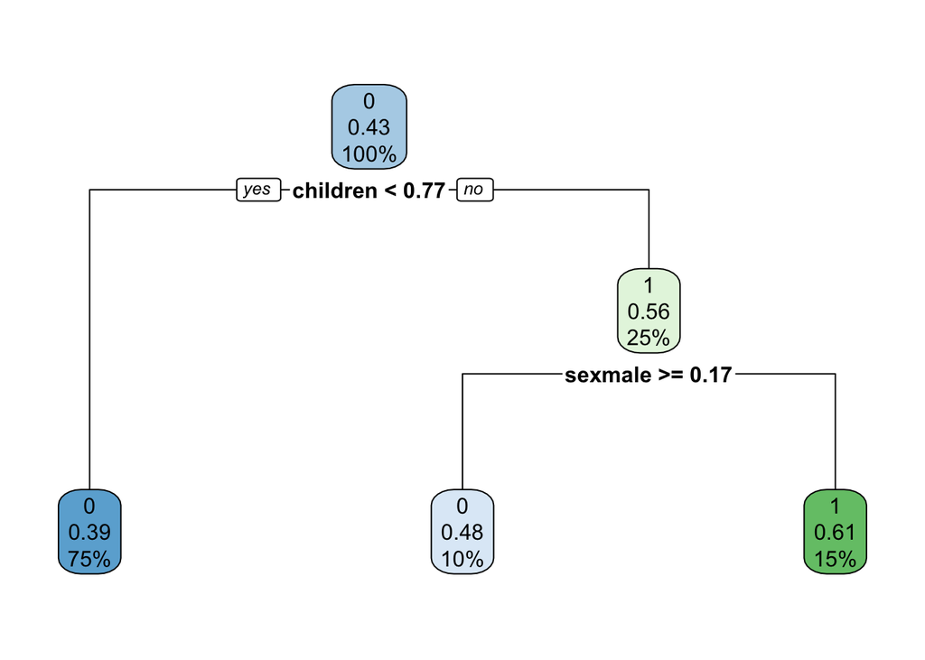

```r
rpart.plot(fit_tree$finalModel)
```

Regression and classification trees are not known for being great predictors. It’s interpretability it what makes it a useful tool. Be careful with how you interpret these trees. They may look nice and fancy, but they can sometimes be unstable and their variances high. But let’s see what outcome it gives when we use it to estimate the propensity score to plug into our regression.

```r
tree_pred <- predict(fit_tree, type = "prob")
exp$tree_ps <- tree_pred$`1`
mod_tree <- lm(Y~D+tree_ps, data=exp)
summary(mod_tree)
```

```
##
## Call:
## lm(formula = Y ~ D + tree_ps, data = exp)
##
## Residuals:
##     Min      1Q  Median      3Q     Max
## -2275.9  -714.7  -168.8   556.2 10408.6
##
## Coefficients:
##             Estimate Std. Error t value            Pr(>|t|)
## (Intercept)  1518.18      65.99   23.00 <0.0000000000000002 ***
## D             575.71      23.77   24.22 <0.0000000000000002 ***
## tree_ps      2389.83     151.36   15.79 <0.0000000000000002 ***
## ---
## Signif. codes:  0 '***' 0.001 '**' 0.01 '*' 0.05 '.' 0.1 ' ' 1
##
## Residual standard error: 1007 on 7492 degrees of freedom
## Multiple R-squared:  0.1157, Adjusted R-squared:  0.1155
## F-statistic: 490.2 on 2 and 7492 DF,  p-value: < 0.00000000000000022
```

How is the fit of this model? Is it better or worse than the logistic regression?

### Random Forests

We’ve estimated a single regression tree, but the variance can sometimes be quite high because of the crude linear splits the model makes. For a better prediction, we can average over a large number of trees. Each different tree is based on a different subsample of the data or on a bootstrap sample. Further, splits at each stage of the tree are optimised over a random subset of the covariates rather than all the covariates.

This means that we end up with lots of random trees. Averaging predictions across them creates smoothness in the predictions. So rather than moving from $x=0.5$ to $x=0.6$ creating a huge jump in $y$ from $5$ to $30$ because we have switched subsamples, it now creates a smoother prediction. This is called a random forest (Breiman, 2001). A random forest is already an ensemble method. We use the prediction of lots of underlying classification trees to produce a better prediction. It removes some of the bias

The usefulness of a random forest is that it is based on the devil we know and understand very well—the regression tree. It also requires very little tuning as it is already an ensemble of trees. They deal very well where there are unimportant variables, creating sparsity. They don’t tend to overfit too much like some of the fancier methods (like neural networks). The random forest is sort of a matching estimator—it finds other households that look similar to the one we’re try to predict the outcome for. But importantly, it matches oly on the most important variables. Importance, in this context, is determined by how often a variable is used as a splitter over lots of estimations.

```r
set.seed(123)
ctrl_forest <- trainControl(method='repeatedcv', number=10, repeats=1)
fit_forest <- train(
  factor(D) ~ income+sex+education+location+children,
  data = exp,
  method = "rf",
  preProc = c("center", "scale"),
  metric='Accuracy',
  trControl = ctrl_forest
)
forest_pred <- predict(fit_forest, type = "prob")
exp$forest_ps <- forest_pred$`1`
mod_rf <- lm(Y~D+forest_ps, data=exp)
summary(mod_rf)
```

```
##
## Call:
## lm(formula = Y ~ D + forest_ps, data = exp)
##
## Residuals:
##     Min      1Q  Median      3Q     Max
## -2457.6  -709.2  -150.7   564.4 10224.6
##
## Coefficients:
##             Estimate Std. Error t value            Pr(>|t|)
## (Intercept)  2404.04      17.99  133.67 <0.0000000000000002 ***
## D             538.51      24.53   21.95 <0.0000000000000002 ***
## forest_ps     590.91      42.22   13.99 <0.0000000000000002 ***
## ---
## Signif. codes:  0 '***' 0.001 '**' 0.01 '*' 0.05 '.' 0.1 ' ' 1
##
## Residual standard error: 1011 on 7492 degrees of freedom
## Multiple R-squared:  0.1096, Adjusted R-squared:  0.1093
## F-statistic:   461 on 2 and 7492 DF,  p-value: < 0.00000000000000022
```

### Gradient Boosting Machines

Gradient Boosting Machines (GBM) are a pretty popular method for machine learning enthusiasts. While random forests create an ensemble of independent but deep trees, GBMs create an ensemble of shallow trees. However, with GBM, these shallow trees are successive, with each one learning from the previous one and improving on it. Its predictive accuracy is usually among the best possible.

```r
set.seed(123)
ctrl_gbm <- trainControl(method = "repeatedcv", repeats = 1)

fit_gbm <- train(
  factor(D) ~ income+sex+education+location+children,
  data = exp,
  method = "gbm",
  preProc = c("center", "scale"),
  trControl = ctrl_gbm,
  verbose = FALSE
)

gbm_pred <- predict(fit_gbm, type="prob")
exp$gbm_ps <- gbm_pred$`1`
mod_gbm <- lm(Y~D+gbm_ps, data=exp)
summary(mod_gbm)
```

```
##
## Call:
## lm(formula = Y ~ D + gbm_ps, data = exp)
##
## Residuals:
##     Min      1Q  Median      3Q     Max
## -2416.7  -707.9  -153.8   558.0 10395.8
##
## Coefficients:
##             Estimate Std. Error t value            Pr(>|t|)
## (Intercept)  1346.12      67.85   19.84 <0.0000000000000002 ***
## D             549.16      23.84   23.03 <0.0000000000000002 ***
## gbm_ps       2812.37     156.83   17.93 <0.0000000000000002 ***
## ---
## Signif. codes:  0 '***' 0.001 '**' 0.01 '*' 0.05 '.' 0.1 ' ' 1
##
## Residual standard error: 1003 on 7492 degrees of freedom
## Multiple R-squared:  0.1239, Adjusted R-squared:  0.1237
## F-statistic: 529.7 on 2 and 7492 DF,  p-value: < 0.00000000000000022
```

## Doubly Robust Estimation

The idea behind doubly robust estimation is kind of like having two spies point their guns at the bad guy. If one doesn’t get him, the other surely will. And you only need one of your spies to hit the bad guy.

If either rebalancing the sample using inverse propensity score weighting or using the conditional mean of outcomes controlling for covariates is specified correctly, then we’ve got the causal estimate. Doubly robust estimation uses both strategies at the same time to try to guarantee a clear estimate. If **either** of these methods are correctly specified—conditional mean or propensity score—then the doubly robust estimator is consistent.

We use both the conditional mean and the propensity score to estimate $\tau$:

$$\tau = \mathbb{E} \left[ \tau(1,X_i) - \tau(0,X_i) + W_i \frac{Y_i-\tau(1,X_i)}{e(X_i)} + (1-W_i) \frac{Y_i-\tau(0,X_i)}{(1-e(X_i))} \right]$$

The first two terms of this expression will give you exactly the same results as the conditional mean. The second two teams of this expression give you the propensity score weighted mean effect. We take the expectation

```r
set.seed(123)
mod_doub <- lm(Y~income*D+sex*D+education*D+location*D+children*D, data=exp)

treatall <- exp %>% mutate(D=1)
treated_pred <- predict(mod_doub, treatall)

treatnone <- exp %>% mutate(D=0)
control_pred <- predict(mod_doub, treatnone)

actual_pred <- predict(mod_doub, exp)

exp <- exp %>%  mutate(G = treated_pred - control_pred + ((D - gbm_ps) * (Y - actual_pred)) / (gbm_ps * (1 - gbm_ps)))

tau_double <- mean(exp$G)
print(tau_double)
```

```
## [1] 548.0248
```

## Which Model Works Best?

Let’s just collect all our estimators into a single table. You’ll notice a few things. First, because we simulated this data, we know what the true average causal effect is. However, because we’ve simulated this data, it means the selection bias is linear and nowhere near as complex as the madness we encounter in the real world. This means when you run these simualtions, the simple linear methods are likely to outperform our nonlinear machine learning methods. In the real world—in the wild—you can almost always expect machine learning methods to outperform our OLS or Logit models.

```r
tau_SDO <- mod_SDO$coefficients["D"]
tau_logit <- mod_logit$coefficients["D"]
tau_logit_w <- mod_logit_w$coefficients["D"]
tau_tree <- mod_tree$coefficients["D"]
tau_rf <- mod_rf$coefficients["D"]
tau_gbm <- mod_gbm$coefficients["D"]

all_estimates <- data.frame(Estimators=c("Tau","Simple Differences in Mean Outcomes",
                                         "Regression Adjustment", "Inverse Propensity Weighting",
                                         "Propensity Score OLS","Classification Tree",
                                         "Random Forest","Gradient Boosting Machines","Doubly Robust with GBM"),
                               Estimates=c(tau, tau_SDO, tau_regadj, tau_logit, tau_logit_w,
                                           tau_tree,tau_rf, tau_gbm, tau_double))

all_estimates <- all_estimates %>% mutate(Error=Estimates-tau)
kable(all_estimates)
```

[output not shown]

## Final Thoughts

There are many more uses for machine learning in economics. Basically wherever you encounter a prediction problem, machine learning can do it better than standard linear methods.

For example, the instrumental variable problem is a part economic problem, part prediction problem. You need to find a good instrument; that relies on economic theory. Once you’ve found your instrument, you need good predictions of how the instrument affects your endogenous covariate. Remember, the reason for the first stage regression is to predict values that you then stick into the second stage regression.

Or you might think of trying to figure out whether a regulation impacted growth as a prediction problem. Compared to other countries, what would growth in this country be if we didn’t change this regulation? We can combine evaluation methods like synthetic control with machine learning to make important causal inferences.

Other methods you might be interested in include the LASSO, ridge regression and elastic net regression. These are regularization regression methods. They tend to shrink the size of coefficients so we don’t overfit our models. Their usefulness is in reducing the variance. This eliminates the influence of noise on your results. You may also consider support vector machines, which ‘raise’ the data to a higher dimension and attempt to split the data in that dimension using a separating hyperplane.

One type of forecasting that economists frequently need to do is forecasting a single times series. Nonlinear ML methods will often give you a better *fit* than a linear regression. However, be very cautious: you won’t really know what’s going on. Use this when you need a good prediction without any real inference. For example, when you need some prediction of an exogenous series so you can predict some policy outcome based on an inferential model. You can check out Time Series Forecasting with K-Nearest Neighbours: https://cran.r-project.org/web/packages/tsfknn/vignettes/tsfknn.html.

While we have focus on supervised learning problems, there are unsupervised learning problems as well. Unsupervised learning is basically the concept of clustering: identifying things that look like one another and grouping them together.

Many of these notes are based on Susan Athey’s tutorials, Athey and Imben’s papers, the work of Mullainathan and Spiess. You can find any information on using R itself on the internet. This is how we learn R—we use it, we make mistakes, we solve them with Google.

## References

Athey, Susan, and Guido W. Imbens. “Machine learning methods that economists should know about.” Annual Review of Economics 11 (2019).

Bils, Mark, Peter J. Klenow, and Benjamin A. Malin. “Resurrecting the role of the product market wedge in recessions.” American Economic Review 108, no. 4-5 (2018): 1118-46.

Forsythe, Eliza. “Why don’t firms hire young workers during recessions?.” University of Illinois (2016).

Mullainathan, Sendhil, and Jann Spiess. “Machine learning: an applied econometric approach.” Journal of Economic Perspectives 31, no. 2 (2017): 87-106.

Rosenbaum, Paul R., and Donald B. Rubin. “The central role of the propensity score in observational studies for causal effects.” Biometrika 70, no. 1 (1983): 41-55.

Stroebel, Johannes, and Joseph Vavra. “House prices, local demand, and retail prices.” Journal of Political Economy 127, no. 3 (2019): 1391-1436.

Wong, Arlene. “Population aging and the transmission of monetary policy to consumption.” In 2016 Meeting Papers, vol. 716. Society for Economic Dynamics, 2016.